# Project 02

Max Wagner

October 8th, 2015

## Mammals

The second set of data I wanted to look at was the pantheria set on mammals. There weren’t any specific goals on the forum post, so I’m going to just do something of my own choosing. I want to look strictly at columns based on body mass, and see if I can find a link between them.

Loading in some libraries

```r
library(stringr)
library(dplyr)
library(tidyr)
library(ggplot2)
```

I’ll start by pulling in the text file and reading it as a table via dplyr.

```r
mammals <- read.table("https://raw.githubusercontent.com/maxwagner/607/master/project02/mammals.txt", sep = "\t", header = TRUE, stringsAsFactors = FALSE)
mammals <- tbl_df(mammals)
```

Now some things to manipulate the column names. First, convert all the names to lowercase, then remove the weird strings on front of some of them.

```r
colnames(mammals) <- tolower(colnames(mammals))
colnames(mammals) <- str_replace(colnames(mammals), "msw05_", "")
colnames(mammals) <- str_replace(colnames(mammals), "x[0-9._]+", "")
```

The next step is choosing a few columns for the names of the mammals, and then any column that contains the string “bodymass.” The next step is to remove the data pieces that were not available, which were labeled as -999. I then unite all the names into one column, as the separate ones are not needed for this set. I then get rid of the columns that have almost no usable data, and follow that with a check for complete cases with the three remaining body mass columns. This effectively turned 5400 rows into 400, all with usable and readable information.

```r
mammals <- select(mammals, order, family, binomial, contains("bodymass"))
mammals[mammals == -999] <- NA
mammals <- unite(mammals, full_name, order, family, binomial, sep = ", ")
mammals <- mammals[,1:4]
mammals <- mammals[complete.cases(mammals),]
```

I’ll compare adult mass to neonate and weaning mass to look for a trend. I want to compare only animals under a certain mass, as large mass mammals such as cetacea follow different rules than most.

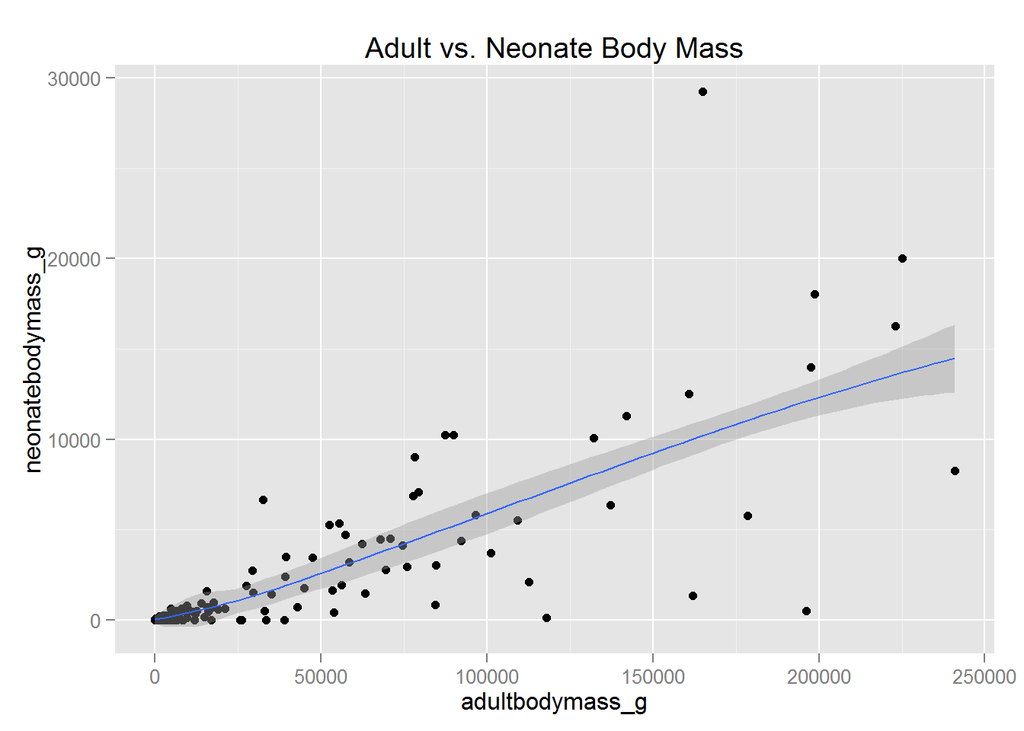

```r
mammals <- subset(mammals, adultbodymass_g < 250000)
qplot(data = mammals, adultbodymass_g, neonatebodymass_g) + ggtitle("Adult vs. Neonate Body Mass") + geom_smooth()
```

```r
cor(mammals$adultbodymass_g, mammals$neonatebodymass_g)
```

```
## [1] 0.8192824
```

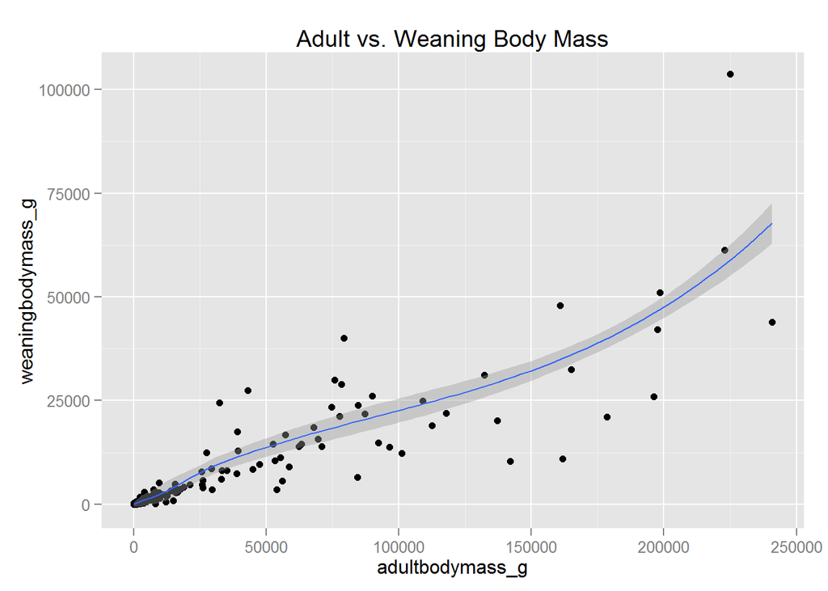

```r
qplot(data = mammals, adultbodymass_g, weaningbodymass_g) + ggtitle("Adult vs. Weaning Body Mass") + geom_smooth()
```

```r
cor(mammals$adultbodymass_g, mammals$weaningbodymass_g)
```

```
## [1] 0.8886534
```

In this case, it looks like both weaning and neonate weight are correlated to adult body weight, as was expected.